# Assignment 1a

Question 1. Part a)

ggplot2 ships with a data set that records the carat size and the price of more than 50 thousand diamonds, from http://www.diamondse.info/ collected in 2008. Consider the analysis presented at https://www.r-bloggers.com/visualization-series-usingscatterplots-and-models-to-understand-the-diamond-market-so-you-dont-getripped-off/

Use methods from Week 1 material and the above (scatterplot matrices, co-plotting, parallel coordinate plotting, ggobi representation, etc.) to explore this dataset and discover interesting relationships and patterns. Present your graphical results along with a written summary of findings.

We will first import the package “ggplot2” in order to access the diamond dataset. We will also import the package “dplyr” to facilitate data manipulation.

```r
library(ggplot2)
library(dplyr)
```

Let us now load in the diamonds dataset

```r
data(diamonds)
```

We will first begin through some exploration of the diamonds dataset. Let us look at the structure of the dataset.

```r
str(diamonds)
```

```
Classes ‘tbl_df’, ‘tbl’ and 'data.frame':   53940 obs. of  10 variables:
 $ carat  : num  0.23 0.21 0.23 0.29 0.31 0.24 0.24 0.26 0.22 0.23 ...
 $ cut    : Ord.factor w/ 5 levels "Fair"<"Good"<..: 5 4 2 4 2 3 3 3 1 3 ...
 $ color  : Ord.factor w/ 7 levels "D"<"E"<"F"<"G"<..: 2 2 2 6 7 7 6 5 2 5 ...
 $ clarity: Ord.factor w/ 8 levels "I1"<"SI2"<"SI1"<..: 2 3 5 4 2 6 7 3 4 5 ...
 $ depth  : num  61.5 59.8 56.9 62.4 63.3 62.8 62.3 61.9 65.1 59.4 ...
 $ table  : num  55 61 65 58 58 57 57 55 61 61 ...
 $ price  : int  326 326 327 334 335 336 336 337 337 338 ...
 $ x      : num  3.95 3.89 4.05 4.2 4.34 3.94 3.95 4.07 3.87 4 ...
 $ y      : num  3.98 3.84 4.07 4.23 4.35 3.96 3.98 4.11 3.78 4.05 ...
 $ z      : num  2.43 2.31 2.31 2.63 2.75 2.48 2.47 2.53 2.49 2.39 ...
```

We can see there are 10 variables, of which the variables “carat”, “depth”, “table”, “price”, “x”, “y”, and “z” are continuous numeric varaibles, and the variables “cut”, “color”, and “clarity” are ordinal factor variables.

Let us begin with some simple histograms of the continuous numeric variables to determine their distributions, and some bar charts of the ordinal factor variables to determine their distributions.

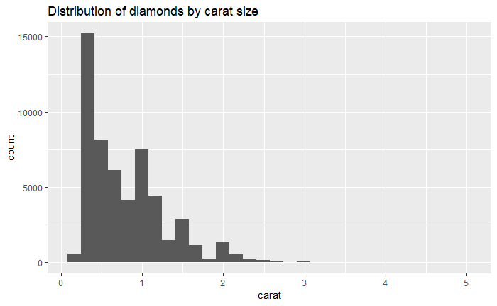

```r
ggplot(diamonds, aes(x = carat)) + geom_histogram() + ggtitle("Distribution of diamonds by carat size")
```

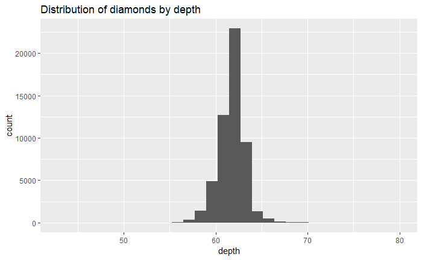

```r
ggplot(diamonds, aes(x = depth)) + geom_histogram() + ggtitle("Distribution of diamonds by depth")
```

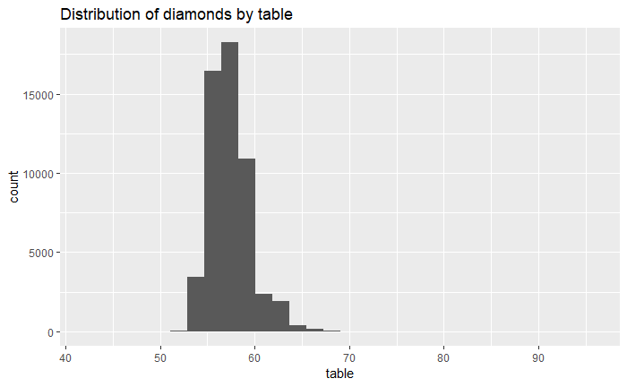

```r
ggplot(diamonds, aes(x = table)) + geom_histogram() + ggtitle("Distribution of diamonds by table")
```

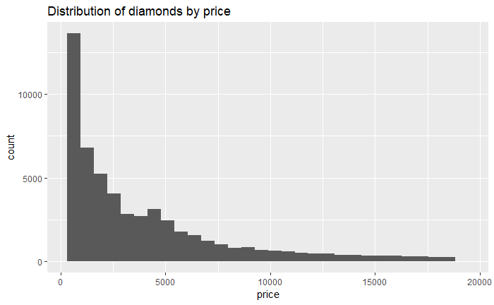

```r
ggplot(diamonds, aes(x = price)) + geom_histogram() + ggtitle("Distribution of diamonds by price")
```

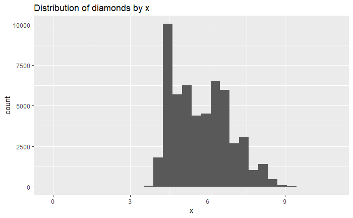

```r
ggplot(diamonds, aes(x = x)) + geom_histogram() + ggtitle("Distribution of diamonds by x")
```

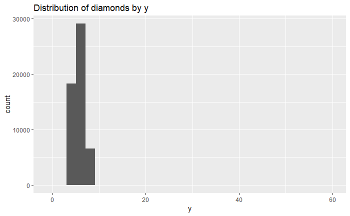

```r
ggplot(diamonds, aes(x = y)) + geom_histogram() + ggtitle("Distribution of diamonds by y")
```

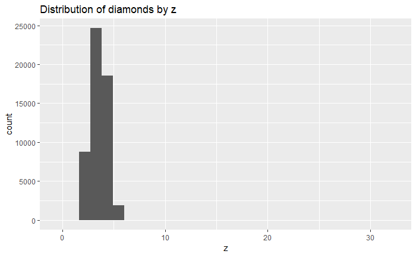

```r
ggplot(diamonds, aes(x = z)) + geom_histogram() + ggtitle("Distribution of diamonds by z")
```

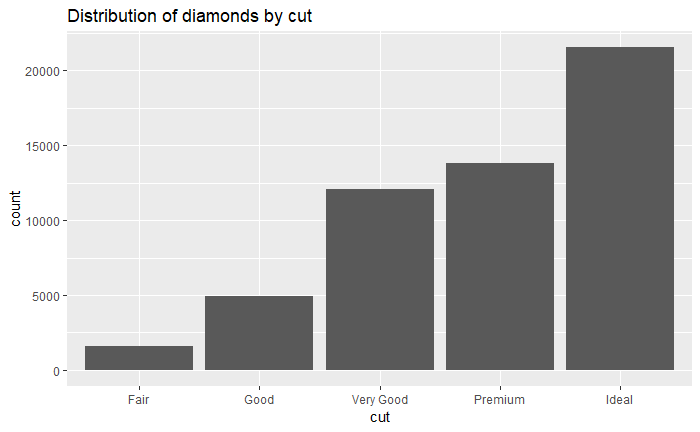

```r
ggplot(diamonds, aes(x = cut)) + geom_bar() + ggtitle("Distribution of diamonds by cut")
```

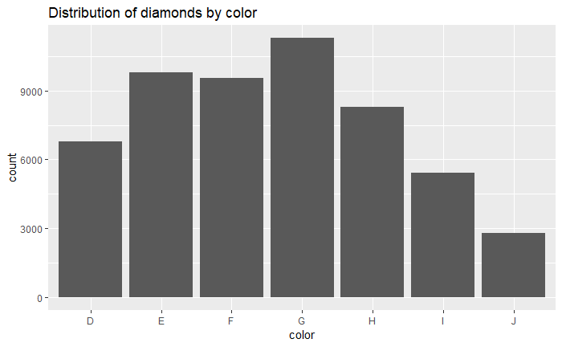

```r
ggplot(diamonds, aes(x = color)) + geom_bar() + ggtitle("Distribution of diamonds by color")
```

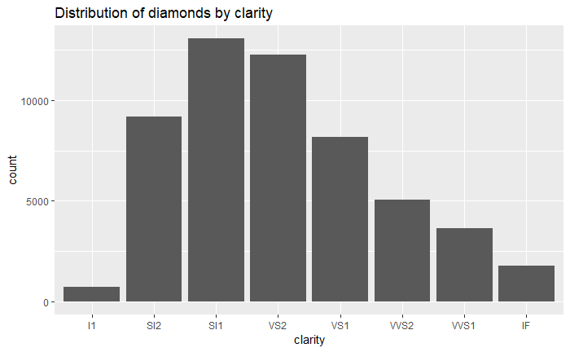

```r
ggplot(diamonds, aes(x = clarity)) + geom_bar() + ggtitle("Distribution of diamonds by clarity")
```

We can display pairwise plots of these variables using the “pairs” function. We will only plot 10000 points, to make the plots more readable.

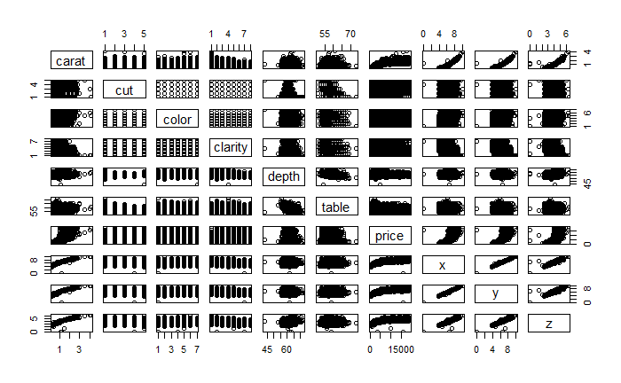

```r
diasamp = diamonds[sample(1:length(diamonds$price), 10000),]
pairs(diasamp)
```

Now let us update the plot slightly using the improvements from the code included on the website.

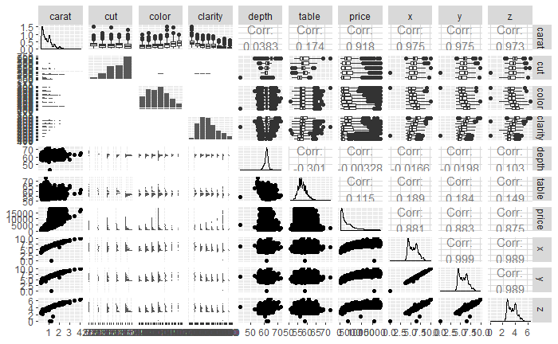

```r
library(GGally)
library(scales)
ggpairs(diasamp)
```

Let us try to find a suitable linear relationship between carat and price. From the histogram of price, we can see that it is highly right-skewed. We can correct for this by placing the price on a log scale, and taking the cube root of carat size.

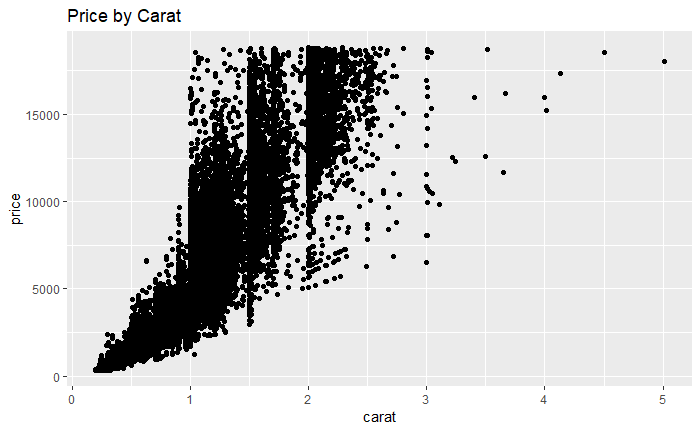

```r
ggplot(diamonds, aes(x = carat, y = price)) + geom_point() + ggtitle("Price by Carat")
```

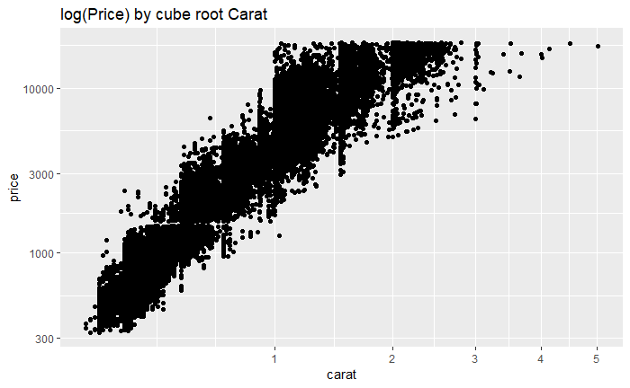

```r
cuberoot_trans = function() trans_new('cuberoot',
                                      transform = function(x) x^(1/3),
                                      inverse = function(x) x^3)
ggplot(diamonds, aes(x = carat, y = price)) +
  geom_point() +
  scale_x_continuous(trans=cuberoot_trans()) +
  scale_y_continuous(trans="log10") +
  ggtitle("log(Price) by cube root Carat")
```

After these transformations, the graph looks linear.

We can now look at the effects of the ordinal variables. Let us color the plot by clarity and see if there’s anything interesting that appears.

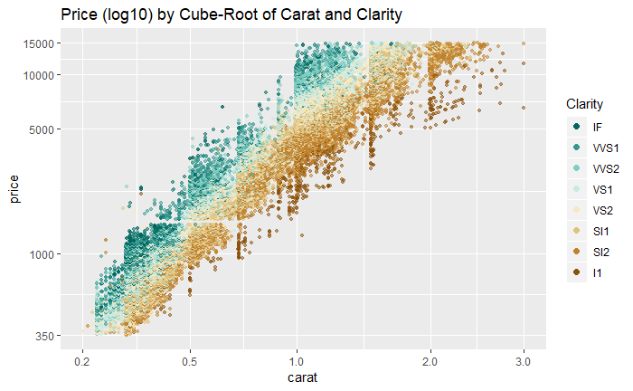

```r
suppressMessages(library(RColorBrewer))
ggplot(aes(x = carat, y = price, color=clarity), data = diamonds) +
  geom_point(alpha = 0.5, size = 1, position = 'jitter') +
  scale_color_brewer(type='div',
                     guide=guide_legend(title='Clarity',
                                        reverse=T,
                                        override.aes=list(alpha=1, size=2))) +
  scale_x_continuous(trans = cuberoot_trans(),
                     limits = c(0.2, 3),
                     breaks = c(0.2, 0.5, 1, 2, 3)) +
  scale_y_continuous(trans = log10_trans(),
                     limits = c(350, 15000),
                     breaks = c(350, 1000, 5000, 10000, 15000)) +
  ggtitle('Price (log10) by Cube-Root of Carat and Clarity')
```

As expected, the lower the clarity, the lower the price.

We can also look at the influence of cut and color on the price as well.

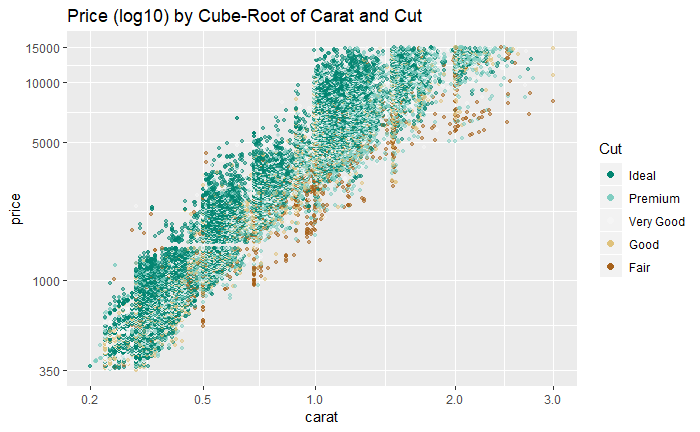

```r
ggplot(aes(x = carat, y = price, color = cut), data = diamonds) +
  geom_point(alpha = 0.5, size = 1, position = 'jitter') +
  scale_color_brewer(type = 'div',
                     guide = guide_legend(title = 'Cut',
                                          reverse = T,
                                          override.aes = list(alpha = 1,
                                                              size = 2))) +
  scale_x_continuous(trans = cuberoot_trans(), limits = c(0.2, 3),
                     breaks = c(0.2, 0.5, 1, 2, 3)) +
  scale_y_continuous(trans = log10_trans(), limits = c(350, 15000),
                     breaks = c(350, 1000, 5000, 10000, 15000)) +
  ggtitle('Price (log10) by Cube-Root of Carat and Cut')
```

The relationship that can be seen is that the better the cut, the higher the price, generally speaking. There are a few low-cut diamonds that fetched higher prices than high-cut diamonds at lower carat sizes, however the general trend stands.

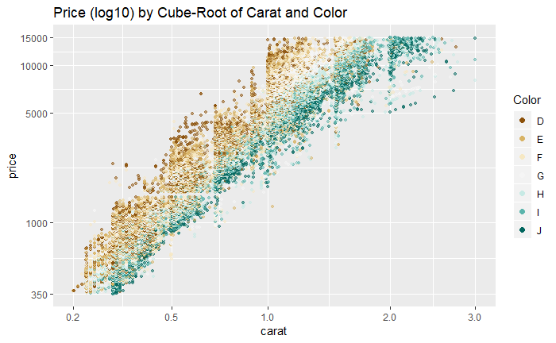

```r
ggplot(aes(x = carat, y = price, color = color), data = diamonds) +
  geom_point(alpha = 0.5, size = 1, position = 'jitter') +
  scale_color_brewer(type = 'div',
                     guide = guide_legend(title = "Color",
                                          reverse = F,
                                          override.aes = list(alpha = 1,
                                                              size = 2))) +
  scale_x_continuous(trans = cuberoot_trans(), limits = c(0.2, 3),
                     breaks = c(0.2, 0.5, 1, 2, 3)) +
  scale_y_continuous(trans = log10_trans(), limits = c(350, 15000),
                     breaks = c(350, 1000, 5000, 10000, 15000)) +
  ggtitle('Price (log10) by Cube-Root of Carat and Color')
```

The lower the color rating, the more colored the diamond. As expected, the high color rating diamonds generally cost more than the low color rating diamonds.

Now let us try some multivariate plots. We will first use GGobi to view a 2D tour of the data to see if any interesting clusters appear. Note that since the diamond dataset has over 50000 entries, visualizing the entire dataset within GGobi will cause the program to crash. As such, we will only use a sample of 1000 entries for viewing.

We know that there are natural clusters within the data corresponding to the variables “clarity”, “cut”, and “color”, since those variables are ordinal factors. As such, we will view our data without those natural cluster variables. This will enable us to see whether there are other interesting clusters that arise from the continuous variables.

We can see from this graph that table seems to create linear clusters within the data:

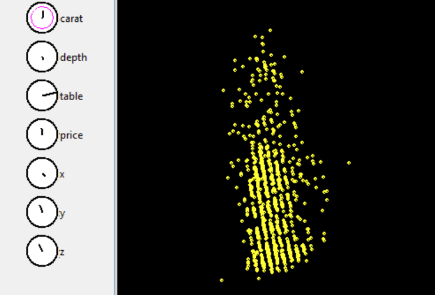

The parallel coordinates plot shows this as well.

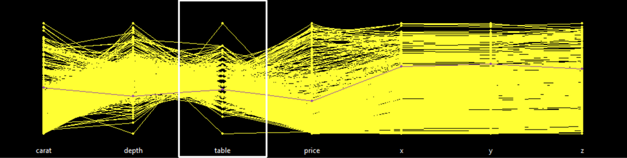

To ensure that this is not an artifact of the sampling, we take a different sample and create the same parallel coordinates plot. The clustering within the table variable is still apparant.

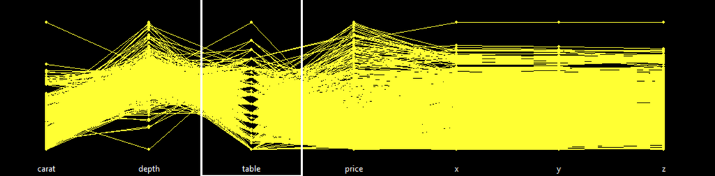

A histogram of the table variable with smaller bins should make the clusters more apparant.

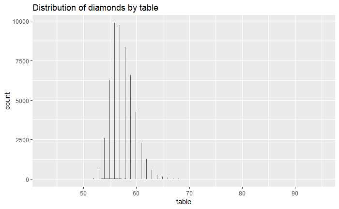